# Maia_MPA_Final_Markdown

Maia Griffith

2023-11-15

## Cumulative Number and Total Area Stuff

Understanding and visualizing the growth of MPAs in the United States over time is a critical piece in acheiving the 30x30 goal. The following code was used to plot the cumulative growth over time of the number of MPAs and the total area of MPAs.

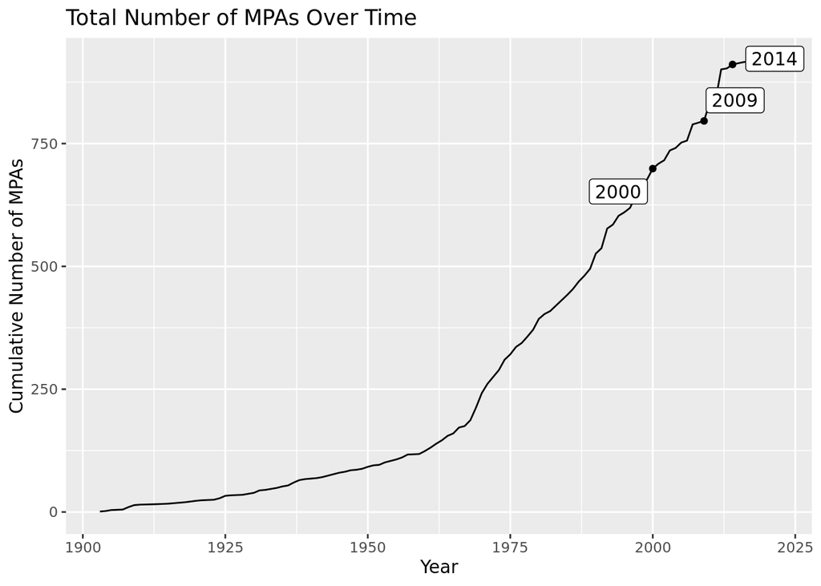

```r
library(ggrepel)

MPA.parks.year <- MPA.data.clean %>%
  mutate("year" = year(Year.Established)) %>%
  group_by(year) %>%
  summarise(count = n()) %>% # Getting the number of parks created per year
  mutate('Cumulative' = cumsum(count)) # Calculating a cumulative sum of the total number of parks per year

# Plot the cumulative sum of NUMBER of MPAs per year to visualize trend over time.
total_num_plot <-
  ggplot(MPA.parks.year) +
  geom_line(aes(x = year,
                y = Cumulative)) +
  labs(title = "Total Number of MPAs Over Time",
       x = "Year",
       y = "Cumulative Number of MPAs") +
  geom_point(data=MPA.parks.year %>% filter(year == 2000| year == 2009| year == 2014),
             aes(x = year,
                 y = Cumulative)) +
  geom_label_repel(data=MPA.parks.year %>% filter(year == 2000| year == 2009| year == 2014),
                                            aes(label = year,
                                                x = year,
                                                y = Cumulative),
                                            box.padding   = 0.35,
                                            point.padding = 0.75)

total_num_plot
```

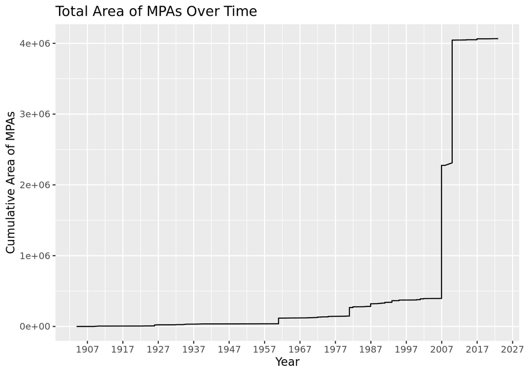

```r
# Wrangle data to have the cumulative total area over time.
MPA.totalarea.year <- MPA.data.clean %>%
  mutate("year" = year(Year.Established)) %>%
  arrange(ymd(MPA.data.clean$Year.Established)) %>%
  mutate('Cum_Area' = cumsum(Area))

# Plot the cumulative sum of AREA of MPAs per year to visualize trend over time.
total_area_plot <-
  ggplot(MPA.totalarea.year) +
  geom_line(aes(x = Year.Established,
                y = Cum_Area)) +
  labs(title = "Total Area of MPAs Over Time",
       x = "Year",
       y = "Cumulative Area of MPAs") +
  scale_x_date(date_breaks = "10 years", date_labels = "%Y")

total_area_plot
```

These plots reveal a strong upward trend of MPAs both in number and in area. However, this does not tell us anything about the strength of the MPAs being created. We decided to focus on MPAs before and after an executive order was released from President Bill Clinton in 2000, which aimed to improve the protections provided from MPAs.

From [Executive Order 13158](https://www.govinfo.gov/content/pkg/WCPD-2000-05-29/pdf/WCPD-2000-05-29-Pg1230.pdf): “To this end, the purpose of this order is to, consistent with domestic and international law: (a) **strengthen** the management, protection, and conservation of existing marine protected areas and **establish new or expanded MPAs**; (b) develop a scientifically based, comprehensive national **system of MPAs** representing diverse U.S. marine ecosystems, and the Nation’s natural and cultural resources; and (c) **avoid causing harm** to MPAs through federally conducted, approved, or funded activities.”

This landmark declaration helped spur the future creation of large and important MPAs in subsequent years. In 2009, [President Bush created](https://www.fws.gov/national-monument/pacific-remote-islands-marine/about-us) the Pacific Remote Islands Marine National Monument just before his presidency ended, and then in 2014, President Obama expanded that MPA to include almost 500,000 square miles of ocean, corals, and small islands.

## T-Test Things

The following code is the data wrangling to create a data frame to use in a two-sided t-test

```
## [1] "No Access"             "No Impact"             "No Take"
## [4] "Uniform Multiple Use"  "Zoned Multiple Use"    "Zoned w/No Take Areas"
```

```
##  [1] ""
##  [2] "Community Agreement"
##  [3] "MPA Management Plan"
##  [4] "MPA Programmatic Management Plan"
##  [5] "No Management Plan"
##  [6] "Non-MPA Programmatic Fisheries Management Plan"
##  [7] "Non-MPA Programmatic Habitat Management Plan"
##  [8] "Non-MPA Programmatic Species Management Plan"
##  [9] "Non-MPA Programmatic Species Management Plan\n"
## [10] "Site-Specific Management Plan"
```

To assign rankings for each Level of Protection and Management Plan, the metadata was used to compare the various types. Low numbers are lower protections, and high numbers are higher protections. Information used along with our rankings (in parenthesis) are below.

**Management Level (1-Low, 7-High):** (1) No Management Plan: No management plan has been developed for the site, or the management plan is still in draft form

2. Community Agreement: A verbal or written community agreement has been reached for the management of the site
3. Non-MPA Programmatic Species Management Plan: A species management plan has been developed, which includes the management of the site
4. Non-MPA Programmatic Fisheries Management Plan: A fisheries management plan has been developed, which includes the management of the site
5. Non-MPA Programmatic Habitat Management Plan: A habitat management plan has been developed, which includes the management of the site
6. MPA Programmatic Management Plan: A management plan has been developed for a broader MPA program, which includes the site
7. Site-Specific Management Plan: A management plan has been developed specifically for the site

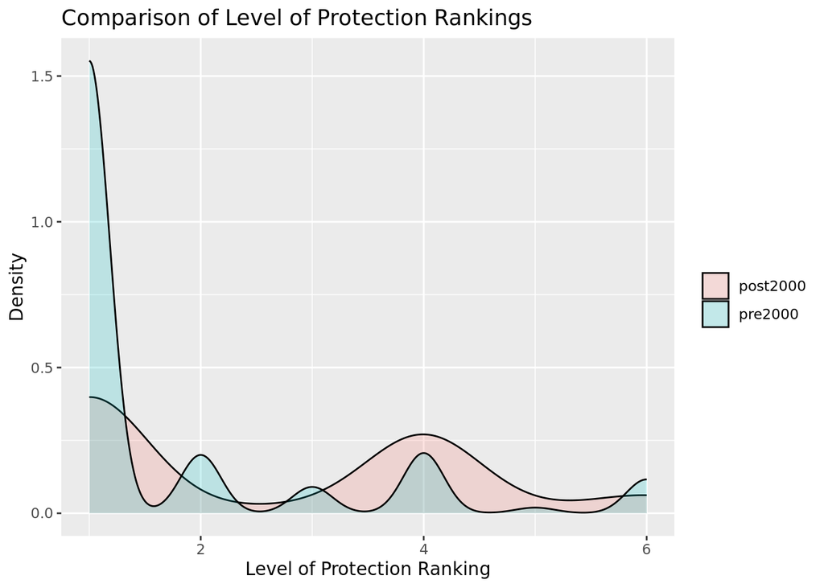

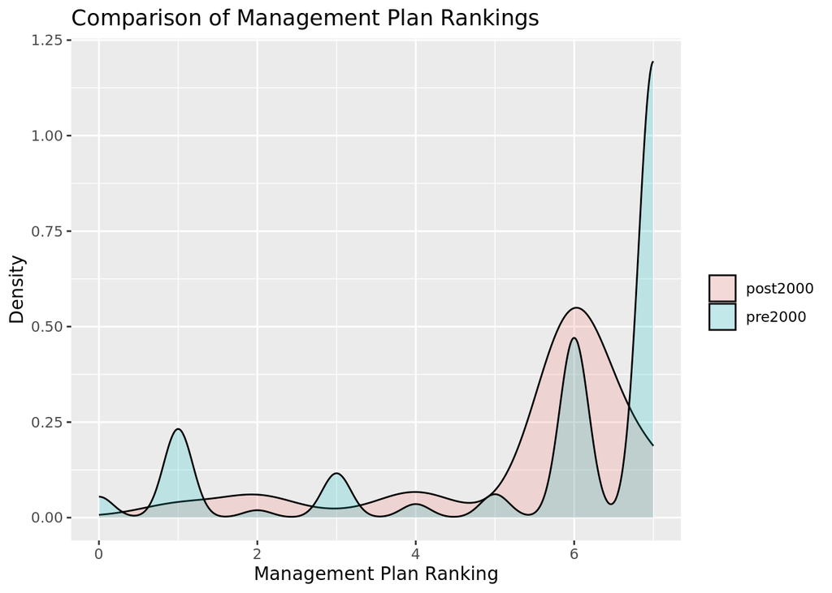

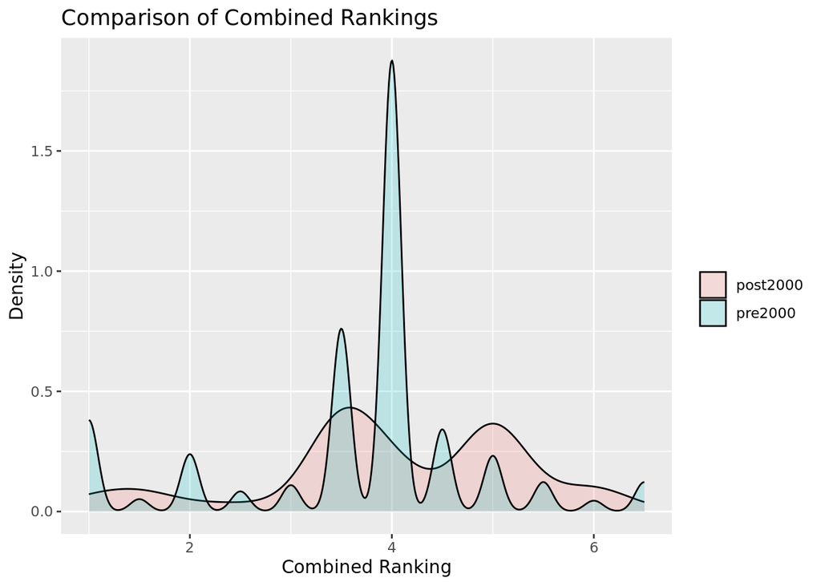

Next, perform the two-sample t-test to compare means before and after 2000 for the Level of Protection, Management Plan, and the Combined Average Ranking.

```
##
##  Welch Two Sample t-test
##
## data:  MPA_ttest_df$Level_Val by MPA_ttest_df$PrePost
## t = 6.4078, df = 362.42, p-value = 4.593e-10
## alternative hypothesis: true difference in means between group post2000 and group pre2000 is not equal to 0
## 95 percent confidence interval:
##  0.5506622 1.0383120
## sample estimates:
## mean in group post2000  mean in group pre2000
##               2.553719               1.759232
```

```
##
##  Welch Two Sample t-test
##
## data:  MPA_ttest_df$Mngmt_Val by MPA_ttest_df$PrePost
## t = -1.1362, df = 574, p-value = 0.2563
## alternative hypothesis: true difference in means between group post2000 and group pre2000 is not equal to 0
## 95 percent confidence interval:
##  -0.4089917  0.1092127
## sample estimates:
## mean in group post2000  mean in group pre2000
##               5.458678               5.608567
```

```
##
##  Welch Two Sample t-test
##
## data:  MPA_ttest_df$Combo_Val by MPA_ttest_df$PrePost
## t = 3.4212, df = 403.16, p-value = 0.0006872
## alternative hypothesis: true difference in means between group post2000 and group pre2000 is not equal to 0
## 95 percent confidence interval:
##  0.1371012 0.5074963
## sample estimates:
## mean in group post2000  mean in group pre2000
##               4.006198               3.683900
```

Results:

When comparing pre-2000 and post-2000 ranked Levels of Protection and Management Plans, we can conclude that overall there appears to a significant difference between the two time periods. For Levels of Protection, the t-test reveals that in the post-2000 era, MPAs were given significantly higher Levels of Protection than before 2000 (p-value = 4.593e-10). For Management Plans, no significant difference was found between the two time periods (p-value = 0.2563). However, when using the combined ranking for the MPAs, which took the average score between Level of Protection and Management Plan, the post-2000 group still had significantly higher protections than the pre-2000 group (p-value = 0.0006872).

This means we can reject our null hypothesis and accept our alternative hypothesis that the pre- and post-2000 groups would have different overall protections. We can also infer that the executive order from President Clinton may have helped make this change, although this cannot be 100% confirmed, as correlation does not always mean causation. Further studies into the creation of each MPA should be done to evaluate the reasons behind various Level of Protection and Management Plan choices.